# Lab 05 - Halloween Candies & Data Viz Improvement

User1, User2, User3 and User4 - Team Name

2026-10-30

### Load packages

```r
library(tidyverse)
library(ggplot2)
```

# Questioning data visualisations

## Image 4

# Data Visualization for Halloween

Ensure that you have the following two lines of code at the top of `lab-05.Rmd` to make the commands available to you.

```r
library(tidyverse)
library(ggplot2)

# Install that package first
# install.packages("fivethirtyeight")
library(fivethirtyeight)
```

```r
candy_df <- candy_rankings
glimpse(candy_df)
```

```
## Rows: 85
## Columns: 13
## $ competitorname   <chr> "100 Grand", "3 Musketeers", "One dime", "One quarter…
## $ chocolate        <lgl> TRUE, TRUE, FALSE, FALSE, FALSE, TRUE, TRUE, FALSE, F…
## $ fruity           <lgl> FALSE, FALSE, FALSE, FALSE, TRUE, FALSE, FALSE, FALSE…
## $ caramel          <lgl> TRUE, FALSE, FALSE, FALSE, FALSE, FALSE, TRUE, FALSE,…
## $ peanutyalmondy   <lgl> FALSE, FALSE, FALSE, FALSE, FALSE, TRUE, TRUE, TRUE, …
## $ nougat           <lgl> FALSE, TRUE, FALSE, FALSE, FALSE, FALSE, TRUE, FALSE,…
## $ crispedricewafer <lgl> TRUE, FALSE, FALSE, FALSE, FALSE, FALSE, FALSE, FALSE…
## $ hard             <lgl> FALSE, FALSE, FALSE, FALSE, FALSE, FALSE, FALSE, FALS…
## $ bar              <lgl> TRUE, TRUE, FALSE, FALSE, FALSE, TRUE, TRUE, FALSE, F…
## $ pluribus         <lgl> FALSE, FALSE, FALSE, FALSE, FALSE, FALSE, FALSE, TRUE…
## $ sugarpercent     <dbl> 0.732, 0.604, 0.011, 0.011, 0.906, 0.465, 0.604, 0.31…
## $ pricepercent     <dbl> 0.860, 0.511, 0.116, 0.511, 0.511, 0.767, 0.767, 0.51…
## $ winpercent       <dbl> 66.97173, 67.60294, 32.26109, 46.11650, 52.34146, 50.…
```

## Exercise 1

How many observations and variables are in this dataset? Did you identify the type of variables, remember that this detail is crucial to create which kind of data visualization in general.

```r
dim(candy_df)
```

```
## [1] 85 13
```

*Write your comments about results*

There are 85 observations (candies) and 13 variables. `competitorname` is a character variable. Nine variables (`chocolate`, `fruity`, `caramel`, `peanutyalmondy`, `nougat`, `crispedricewafer`, `hard`, `bar`, `pluribus`) are logical (TRUE/FALSE), so they are categorical. The other three (`sugarpercent`, `pricepercent`, `winpercent`) are numerical.

# Data viz - One variable at a time

Just to use the logical variables as categories, run the following code chunk first!

```r
candy_df <- candy_df %>%
  mutate(across(where(is.logical), as_factor))
```

## Exercise 2

Complete the following code to get the data viz to represent “how many candies contain caramel via bar plot”. Fill in the blanks, remove the # symbol in front of your code and the execute the code chunk via green play button.

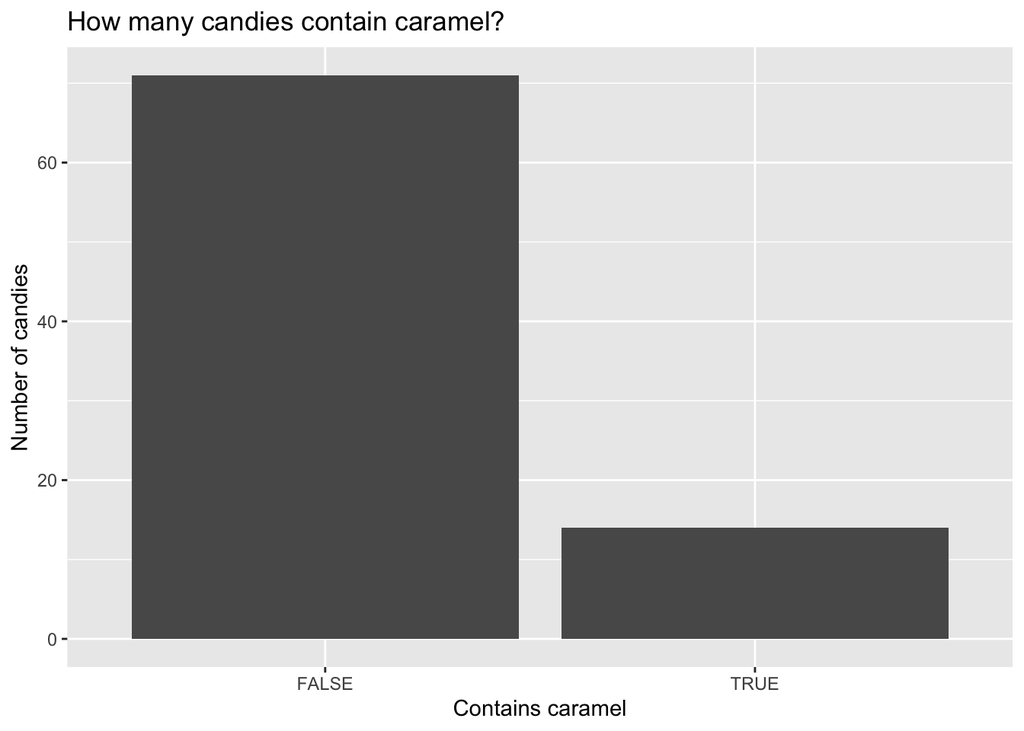

```r
ggplot(candy_df, aes(x = caramel)) +
  geom_bar() +
  labs(
    x = "Contains caramel",
    y = "Number of candies",
    title = "How many candies contain caramel?"
  )
```

Most candies do not contain caramel; only a small number do.

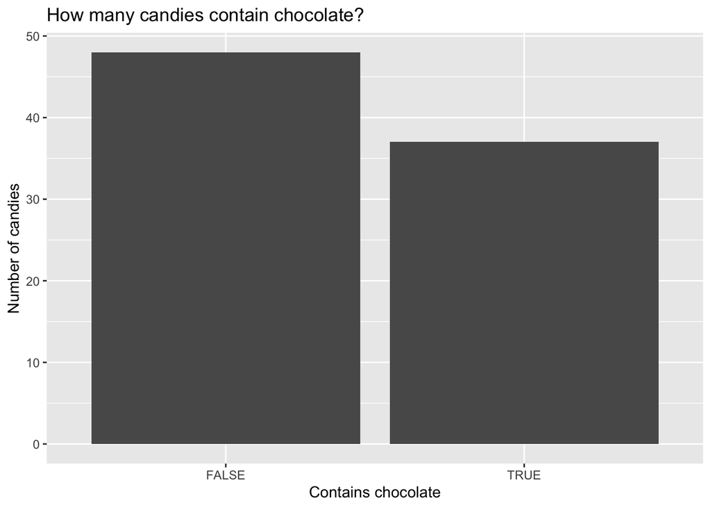

```r
ggplot(candy_df, aes(x = chocolate)) +
  geom_bar() +
  labs(
    x = "Contains chocolate",
    y = "Number of candies",
    title = "How many candies contain chocolate?"
  )
```

For chocolate the split is more even, but there are still slightly more candies without chocolate.

## Exercise 3

Now look at a numerical variable, such as `winpercent`. Create an histogram for this variable using ggplot2 functions below. Include informative x and y labels and a title, as a good practice.

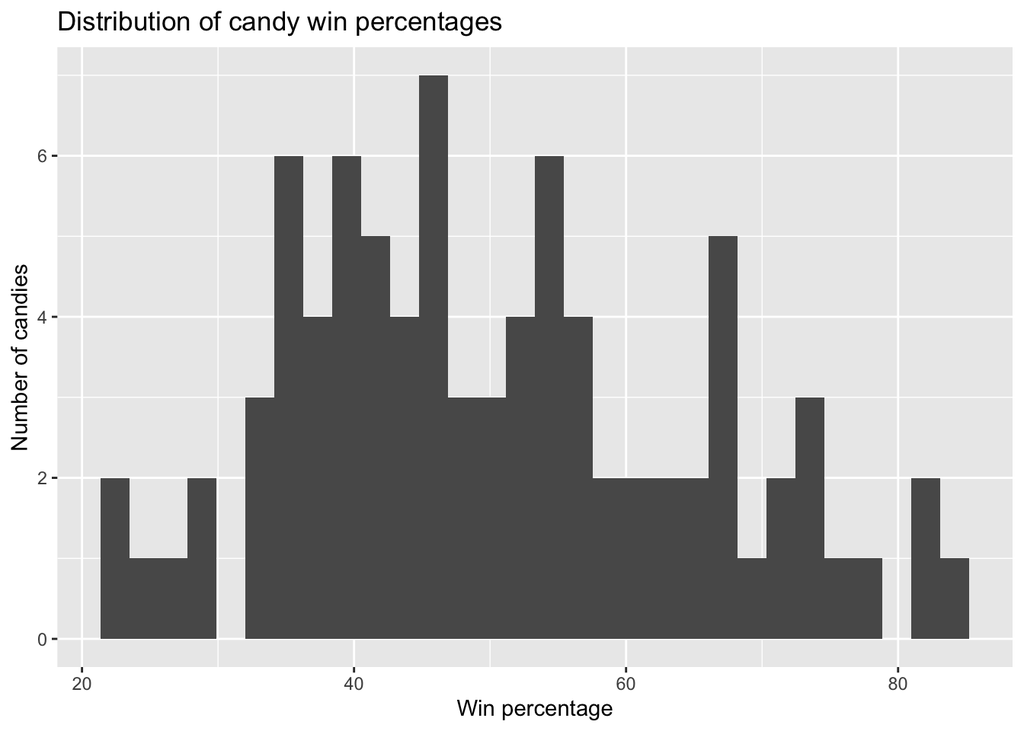

```r
ggplot(candy_df, aes(x = winpercent)) +
  geom_histogram() +
  labs(
    x = "Win percentage",
    y = "Number of candies",
    title = "Distribution of candy win percentages"
  )
```

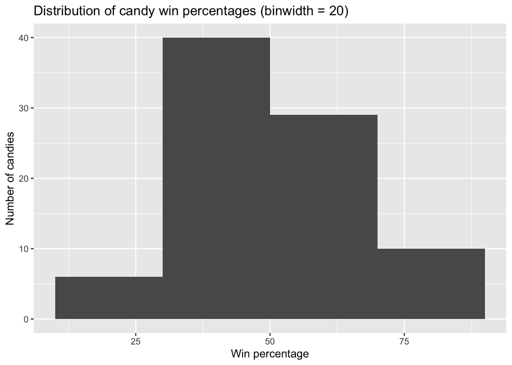

```r
ggplot(candy_df, aes(x = winpercent)) +
  geom_histogram(binwidth = 20) +
  labs(
    x = "Win percentage",
    y = "Number of candies",
    title = "Distribution of candy win percentages (binwidth = 20)"
  )
```

Most candies win between about 35% and 60% of their match-ups, and only a few win more than 75%. With `binwidth = 20` there are only a few wide bars, so the shape is smoother but we lose a lot of detail.

# Data viz - more than one variable

## Exercise 4

How about using the both variables; chocolate vs winpercent? Run the following incomplete code snippet to get a faceted visualization.

Fill in the blanks, remove the # symbol in front of your code and the execute the code chunk via green play button.

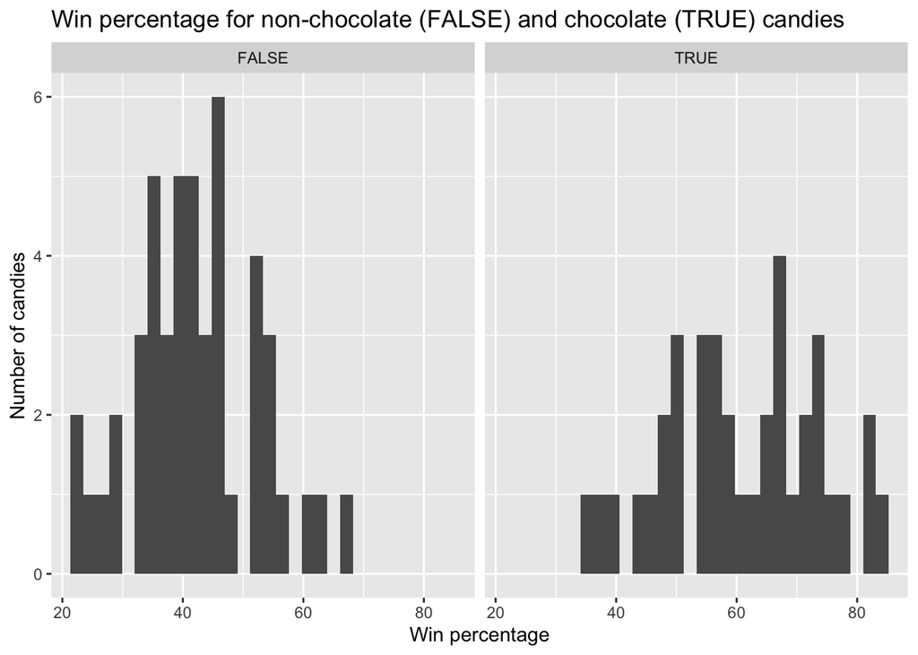

```r
ggplot(candy_df, aes(x = winpercent)) +
  geom_histogram() +
  facet_wrap(~ chocolate) +
  labs(
    x = "Win percentage",
    y = "Number of candies",
    title = "Win percentage for non-chocolate (FALSE) and chocolate (TRUE) candies"
  )
```

- Consider adding the `fill = caramel` within the aes() vs. geom_histogram(), what do you get?

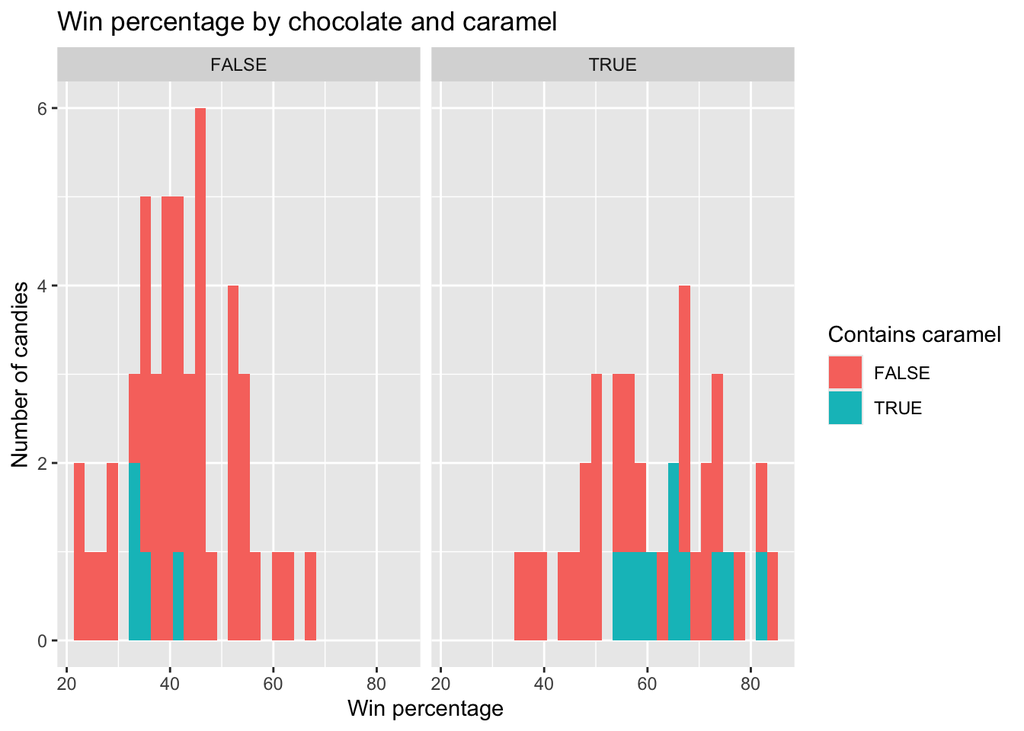

```r
ggplot(candy_df, aes(x = winpercent, fill = caramel)) +
  geom_histogram() +
  facet_wrap(~ chocolate) +
  labs(
    x = "Win percentage",
    y = "Number of candies",
    fill = "Contains caramel",
    title = "Win percentage by chocolate and caramel"
  )
```

## Exercise 5

Create a visualization that examines the relationship between a candy’s win percentage and whether it contains chocolate. Include x and y labels and a title. Describe any relationship you see.

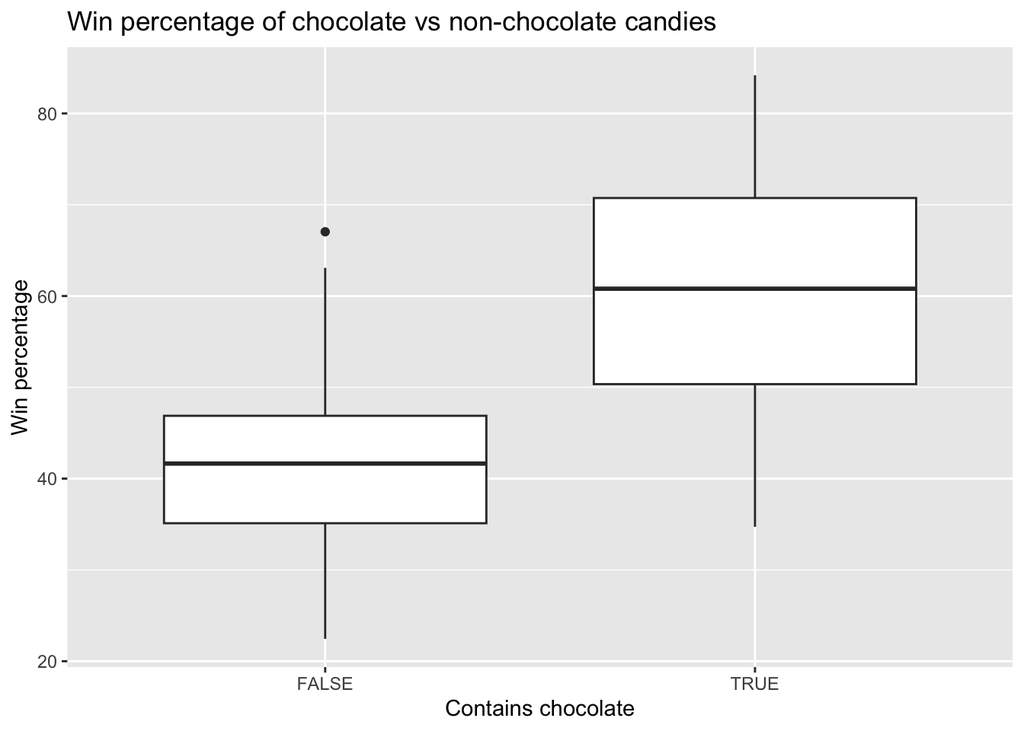

```r
ggplot(candy_df, aes(x = chocolate, y = winpercent)) +
  geom_boxplot() +
  labs(
    x = "Contains chocolate",
    y = "Win percentage",
    title = "Win percentage of chocolate vs non-chocolate candies"
  )
```

Chocolate candies win much more often: the whole box for chocolate candies is higher than the box for non-chocolate candies.

- Consider the similar pair by replacing chocolate with caramel, fruity and compare their results.

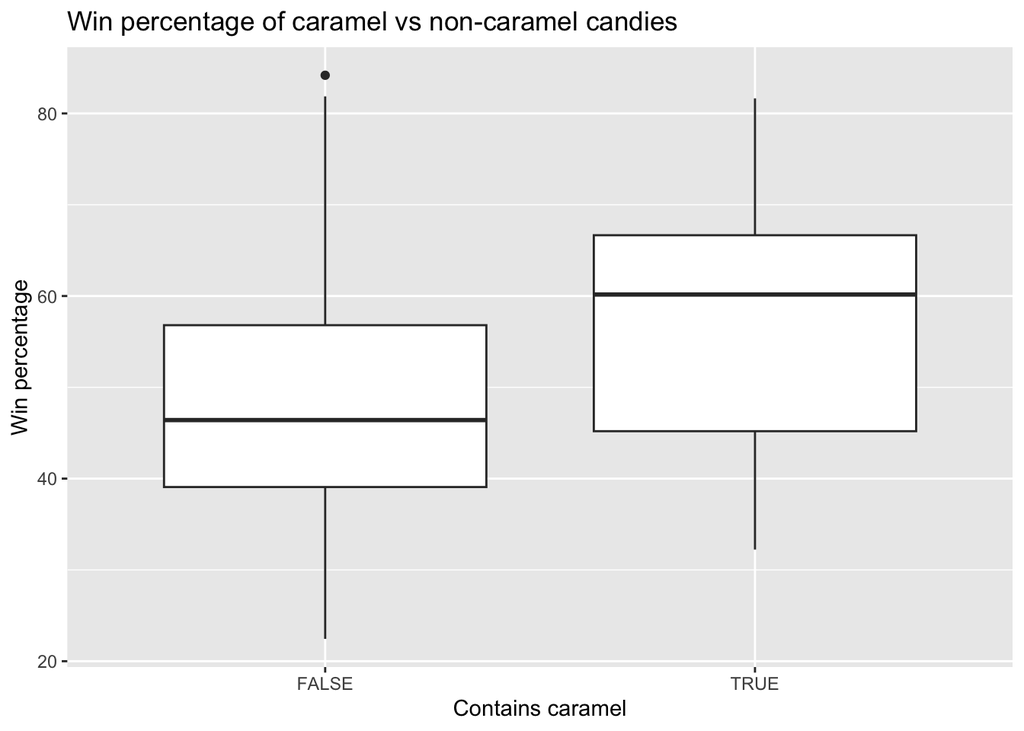

```r
ggplot(candy_df, aes(x = caramel, y = winpercent)) +
  geom_boxplot() +
  labs(
    x = "Contains caramel",
    y = "Win percentage",
    title = "Win percentage of caramel vs non-caramel candies"
  )
```

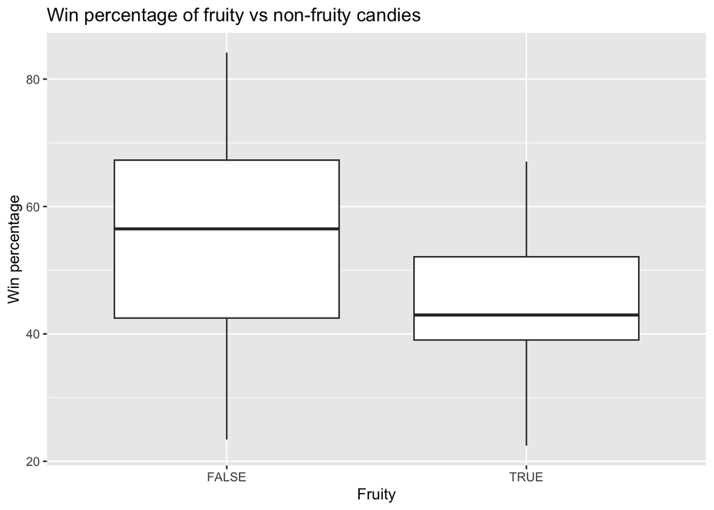

```r
ggplot(candy_df, aes(x = fruity, y = winpercent)) +
  geom_boxplot() +
  labs(
    x = "Fruity",
    y = "Win percentage",
    title = "Win percentage of fruity vs non-fruity candies"
  )
```

- Also include summary statistics details for this discussion by using the calculation below:

```r
candy_rankings %>%
  group_by(chocolate) %>%
  summarise(
    n = n(),
    mean_win = mean(winpercent),
    median_win = median(winpercent)
  )
```

```
## # A tibble: 2 × 4
##   chocolate     n mean_win median_win
##   <lgl>     <int>    <dbl>      <dbl>
## 1 FALSE        48     42.1       41.6
## 2 TRUE         37     60.9       60.8
```

```r
candy_rankings %>%
  group_by(caramel) %>%
  summarise(
    n = n(),
    mean_win = mean(winpercent),
    median_win = median(winpercent)
  )
```

```
## # A tibble: 2 × 4
##   caramel     n mean_win median_win
##   <lgl>   <int>    <dbl>      <dbl>
## 1 FALSE      71     48.9       46.4
## 2 TRUE       14     57.3       60.2
```

```r
candy_rankings %>%
  group_by(fruity) %>%
  summarise(
    n = n(),
    mean_win = mean(winpercent),
    median_win = median(winpercent)
  )
```

```
## # A tibble: 2 × 4
##   fruity     n mean_win median_win
##   <lgl>  <int>    <dbl>      <dbl>
## 1 FALSE     47     55.3       56.5
## 2 TRUE      38     44.1       43.0
```

Chocolate has the biggest effect: the mean and median win percentage are much higher for chocolate candies. Caramel candies also win a bit more often, but there are only a few of them. Fruity candies win less often than non-fruity candies, probably because most fruity candies do not contain chocolate.

## Exercise 6

Do more expensive candies win more often? Make a scatterplot of pricepercent (x) against winpercent (y). Describe their relationship.

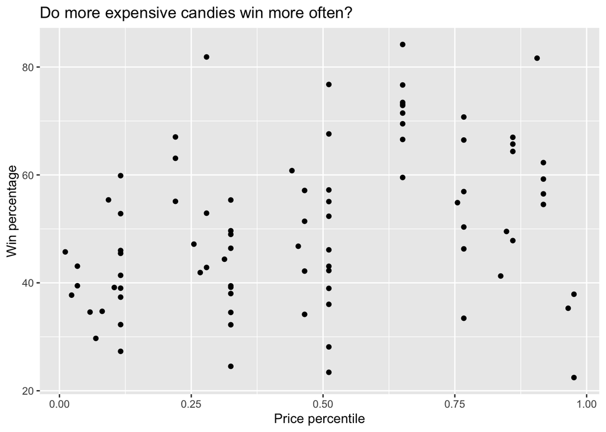

```r
ggplot(candy_df, aes(x = pricepercent, y = winpercent)) +
  geom_point() +
  labs(
    x = "Price percentile",
    y = "Win percentage",
    title = "Do more expensive candies win more often?"
  )
```

There is a weak positive relationship: more expensive candies tend to win a little more often, but the points are very spread out.

- Add `color = chocolate` to add a third variable to the created visualization

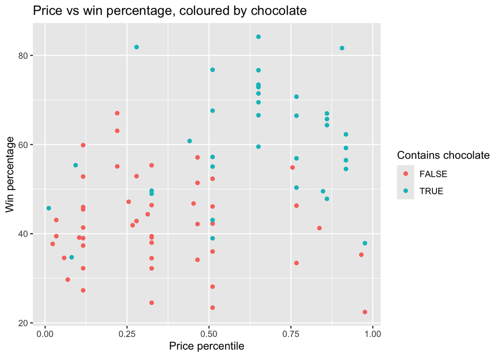

```r
ggplot(candy_df, aes(x = pricepercent, y = winpercent, color = chocolate)) +
  geom_point() +
  labs(
    x = "Price percentile",
    y = "Win percentage",
    color = "Contains chocolate",
    title = "Price vs win percentage, coloured by chocolate"
  )
```

The chocolate candies are mostly in the top right: they are more expensive and win more often.

- How to facet this by using another categorical variable such as `bar`?

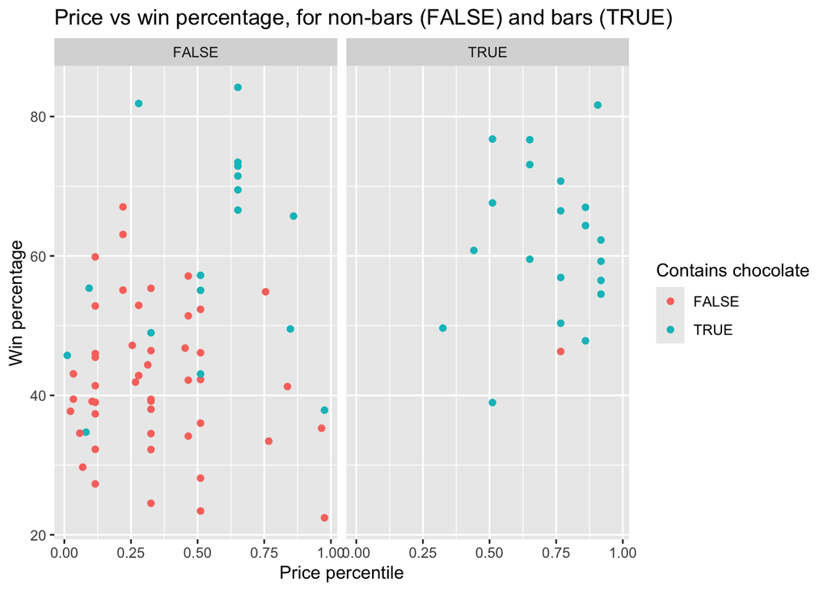

```r
ggplot(candy_df, aes(x = pricepercent, y = winpercent, color = chocolate)) +
  geom_point() +
  facet_wrap(~ bar) +
  labs(
    x = "Price percentile",
    y = "Win percentage",
    color = "Contains chocolate",
    title = "Price vs win percentage, for non-bars (FALSE) and bars (TRUE)"
  )
```

## Exercise 7

Are chocolate candies more likely to be candy bars? Make a filled bar plot with chocolate on the x-axis and fill = bar. Describe what you see.

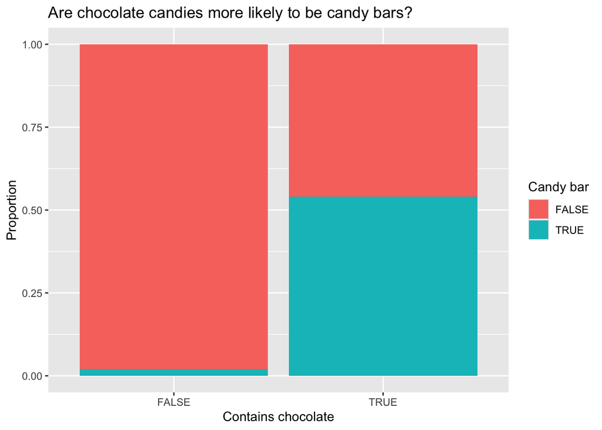

```r
ggplot(candy_df, aes(x = chocolate, fill = bar)) +
  geom_bar(position = "fill") +
  labs(
    x = "Contains chocolate",
    y = "Proportion",
    fill = "Candy bar",
    title = "Are chocolate candies more likely to be candy bars?"
  )
```

Yes. More than half of the chocolate candies are bars, but almost none of the non-chocolate candies are bars.

## Exercise 8

Create a new variable called price per sugar ratio as the division of pricepercent and sugarpercent. Plot it against winpercent, and set the color of all points to blue for the competitors who are not “One dime” or “One quarter”. Include x and y labels and a title. Describe any relationship you see.

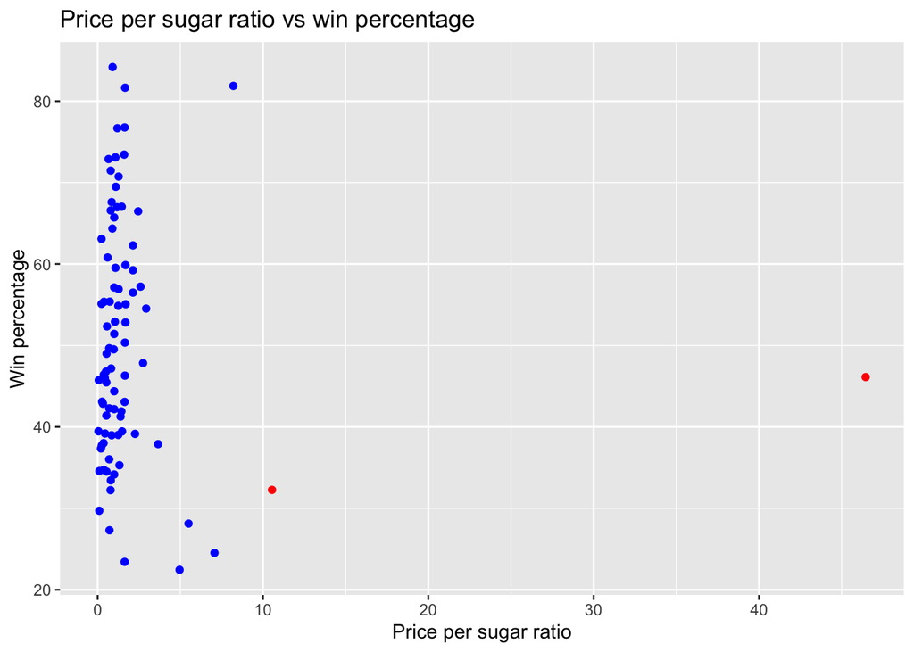

```r
candy_df <- candy_df %>%
  mutate(price_sugar_ratio = pricepercent / sugarpercent)

ggplot(candy_df, aes(x = price_sugar_ratio, y = winpercent)) +
  geom_point(data = filter(candy_df, !competitorname %in% c("One dime", "One quarter")),
             color = "blue") +
  geom_point(data = filter(candy_df, competitorname %in% c("One dime", "One quarter")),
             color = "red") +
  labs(
    x = "Price per sugar ratio",
    y = "Win percentage",
    title = "Price per sugar ratio vs win percentage"
  )
```

“One dime” and “One quarter” (red) are extreme outliers: they have almost no sugar, so dividing by a very small sugarpercent gives a huge ratio, and they also have low win percentages. For the other candies (blue) there is no clear relationship between the price per sugar ratio and the win percentage.

## Exercise 9

Modify your plot in Exercise 8 to facet by whether a candy is bar-shaped. Have the color reflect whether the candy is fruity or not. The plot must include x and y labels along with a title. How do these plots compare to each other?

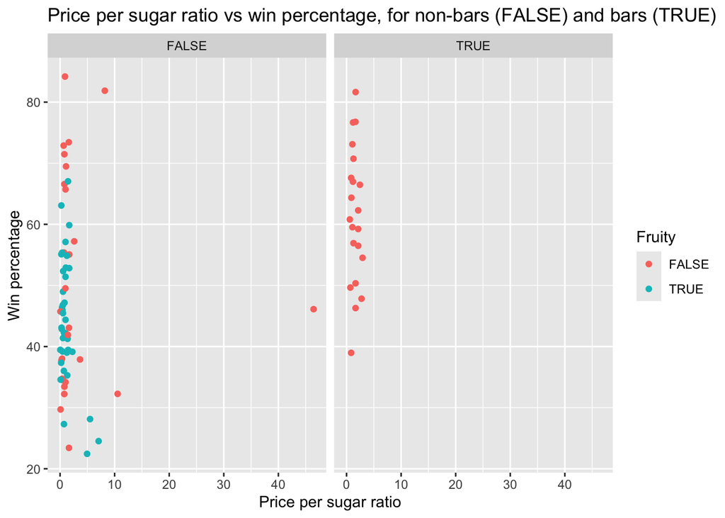

```r
ggplot(candy_df, aes(x = price_sugar_ratio, y = winpercent, color = fruity)) +
  geom_point() +
  facet_wrap(~ bar) +
  labs(
    x = "Price per sugar ratio",
    y = "Win percentage",
    color = "Fruity",
    title = "Price per sugar ratio vs win percentage, for non-bars (FALSE) and bars (TRUE)"
  )
```

None of the bar candies are fruity, and the bars mostly have fairly high win percentages and small ratios. The non-bar panel has all the fruity candies, a much wider range of win percentages, and the two extreme outliers. In both panels there is no clear relationship between the ratio and win percentage.

# Take a sad plot and make it better!

```r
staff <- read_csv("data/instructional-staff.csv")
```

## Exercise 1

What is the difference between *wide format* data and *long format* data?

In wide format, one variable is spread across many columns (here, each year has its own column). In long format, each row is one observation: there is one column for the variable (e.g. `year`) and one column for the value (e.g. `percent`).

Is the format `staff` data *wide* or *long*?

The `staff` data is in wide format.

How many observations are there in the data set?

```r
staff
```

```
## # A tibble: 5 × 12
##   faculty_type    `1975` `1989` `1993` `1995` `1999` `2001` `2003` `2005` `2007`
##   <chr>            <dbl>  <dbl>  <dbl>  <dbl>  <dbl>  <dbl>  <dbl>  <dbl>  <dbl>
## 1 Full-Time Tenu…   29     27.6   25     24.8   21.8   20.3   19.3   17.8   17.2
## 2 Full-Time Tenu…   16.1   11.4   10.2    9.6    8.9    9.2    8.8    8.2    8
## 3 Full-Time Non-…   10.3   14.1   13.6   13.6   15.2   15.5   15     14.8   14.9
## 4 Part-Time Facu…   24     30.4   33.1   33.2   35.5   36     37     39.3   40.5
## 5 Graduate Stude…   20.5   16.5   18.1   18.8   18.7   19     20     19.9   19.5
## # ℹ 2 more variables: `2009` <dbl>, `2011` <dbl>
```

```r
dim(staff)
```

```
## [1]  5 12
```

There are 5 rows (one per faculty type) and 12 columns (`faculty_type` plus 11 years), so there are 5 × 11 = 55 observations (percentages).

## Exercise 2

```r
staff_long <- staff %>%
  pivot_longer(
    cols = -faculty_type,
    names_to = "year",
    values_to = "percent"
    )

staff_long
```

```
## # A tibble: 55 × 3
##    faculty_type              year  percent
##    <chr>                     <chr>   <dbl>
##  1 Full-Time Tenured Faculty 1975     29
##  2 Full-Time Tenured Faculty 1989     27.6
##  3 Full-Time Tenured Faculty 1993     25
##  4 Full-Time Tenured Faculty 1995     24.8
##  5 Full-Time Tenured Faculty 1999     21.8
##  6 Full-Time Tenured Faculty 2001     20.3
##  7 Full-Time Tenured Faculty 2003     19.3
##  8 Full-Time Tenured Faculty 2005     17.8
##  9 Full-Time Tenured Faculty 2007     17.2
## 10 Full-Time Tenured Faculty 2009     16.8
## # ℹ 45 more rows
```

`staff_long` has 55 rows, one for each faculty type and year.

## Exercise 3

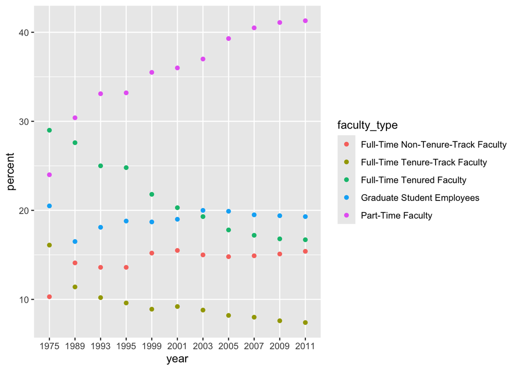

```r
ggplot(staff_long, aes(x = year, y = percent, color = faculty_type)) +
  geom_point()
```

## Exercise 4

```
## `geom_line()`: Each group consists of only one observation.
## ℹ Do you need to adjust the group aesthetic?
```

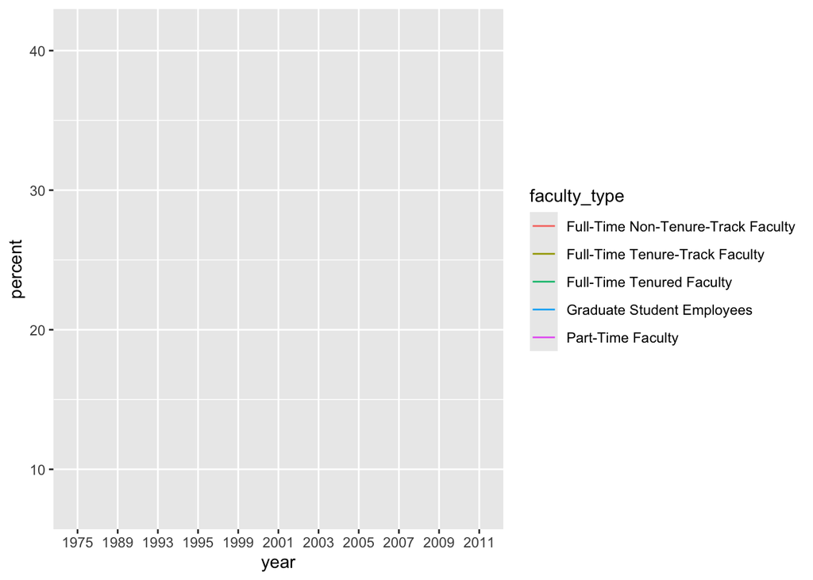

```r
ggplot(staff_long, aes(x = year, y = percent, color = faculty_type)) +
  geom_line()
```

No lines are drawn. This is because `year` is a character variable, so ggplot treats each year as its own group with only one point, and there is nothing to join.

## Exercise 5

```r
staff_long <- staff_long %>%
  mutate(year = as.numeric(year))
```

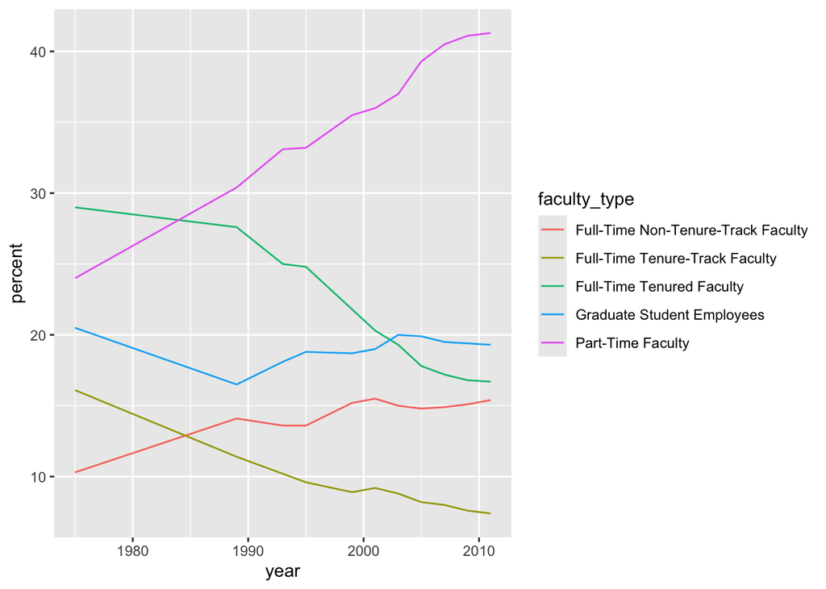

```r
ggplot(staff_long, aes(x = year, y = percent, color = faculty_type)) +
  geom_line()
```

## Exercise 6

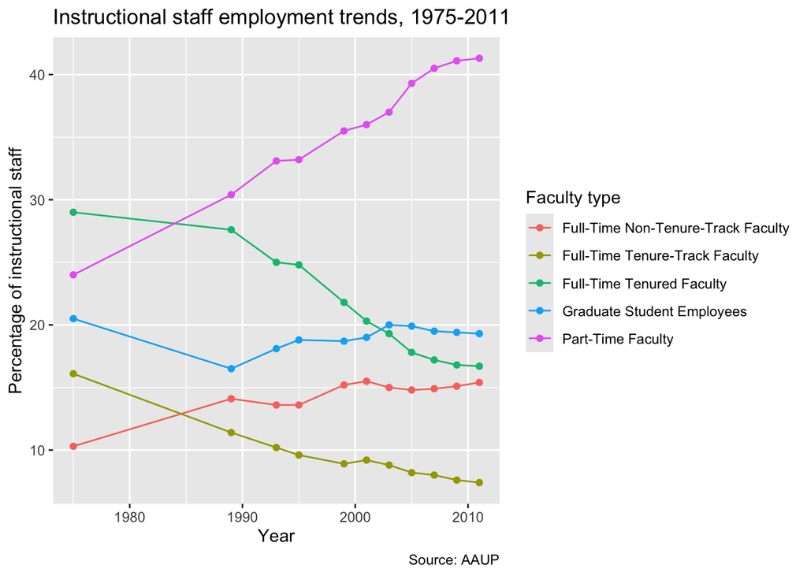

```r
ggplot(staff_long, aes(x = year, y = percent, color = faculty_type)) +
  geom_line() +
  geom_point() +
  labs(
    x = "Year",
    y = "Percentage of instructional staff",
    color = "Faculty type",
    title = "Instructional staff employment trends, 1975-2011",
    caption = "Source: AAUP"
  )
```

## Exercise 7

*Write below your ideas for adapting the line plot*

- Idea 1: Make the part-time faculty line a strong colour and all the other lines grey, so it stands out.
- Idea 2: Group all the other staff types together as “Other” and compare them with part-time faculty.
- Idea 3: Put the main message in the title, e.g. “Part-time faculty increased from 24% to 41%”.

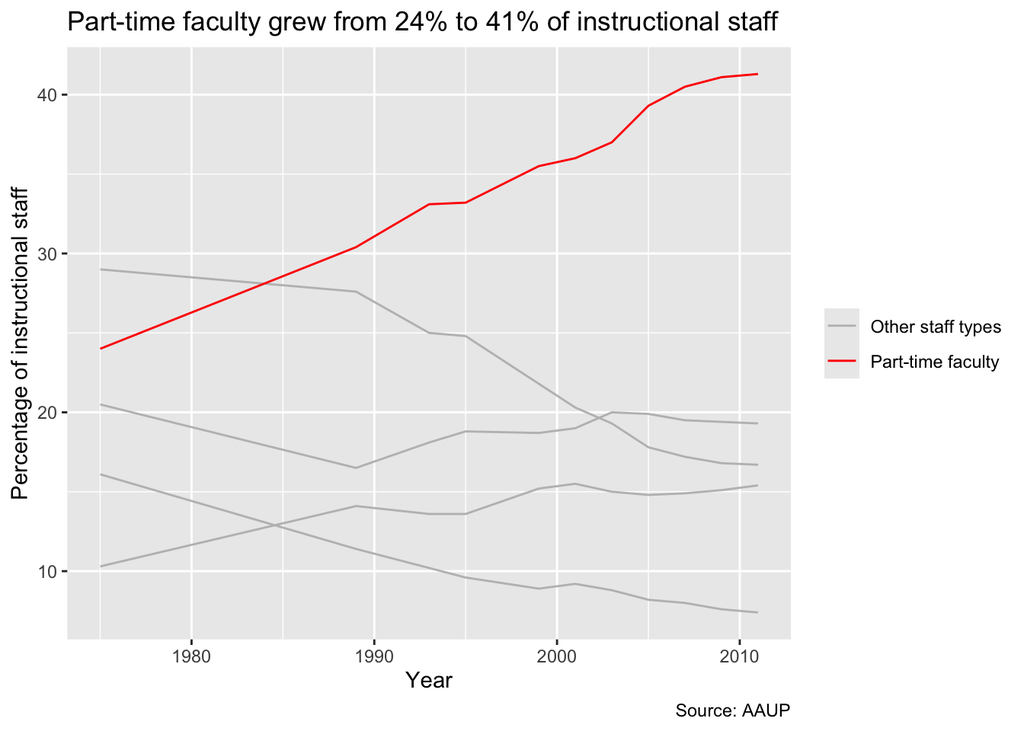

```r
staff_long <- staff_long %>%
  mutate(part_time = if_else(faculty_type == "Part-Time Faculty",
                             "Part-time faculty", "Other staff types"))

ggplot(staff_long, aes(x = year, y = percent, group = faculty_type, color = part_time)) +
  geom_line() +
  scale_color_manual(values = c("Part-time faculty" = "red",
                                "Other staff types" = "grey")) +
  labs(
    x = "Year",
    y = "Percentage of instructional staff",
    color = NULL,
    title = "Part-time faculty grew from 24% to 41% of instructional staff",
    caption = "Source: AAUP"
  )
```

I used ideas 1 and 3. The part-time faculty line is the only coloured line (red), and all the other staff types are grey, so they are still there for comparison but do not distract from the main story. I used `group = faculty_type` so that each staff type still gets its own line even though several of them share the same grey colour. The title states the main message directly so the reader knows what to look for.